# Assignment 5

Yuchen Shi

4/13/2018

# Q#1

According to the formula for F, we calculate our test statistic:

```r
((0.7-0.6)/2)/((1-0.7)/(1000-5-1))
```

```
## [1] 165.6667
```

# Q#2

```r
b  <- read.csv("~/Desktop/ITP 350/Cars93.txt", sep="")

library(dplyr)
```

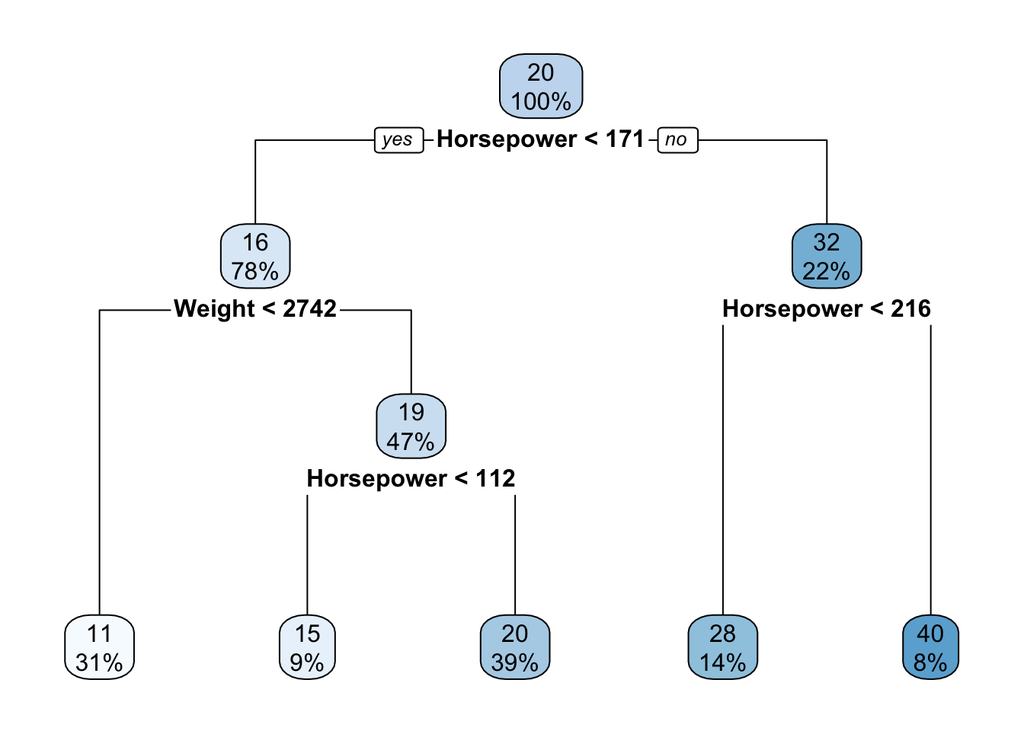

```r
library(rpart)
rpart_model <- rpart(Price~Horsepower+Weight, data=b, method="anova")
library(rpart.plot)
rpart.plot(rpart_model)
```

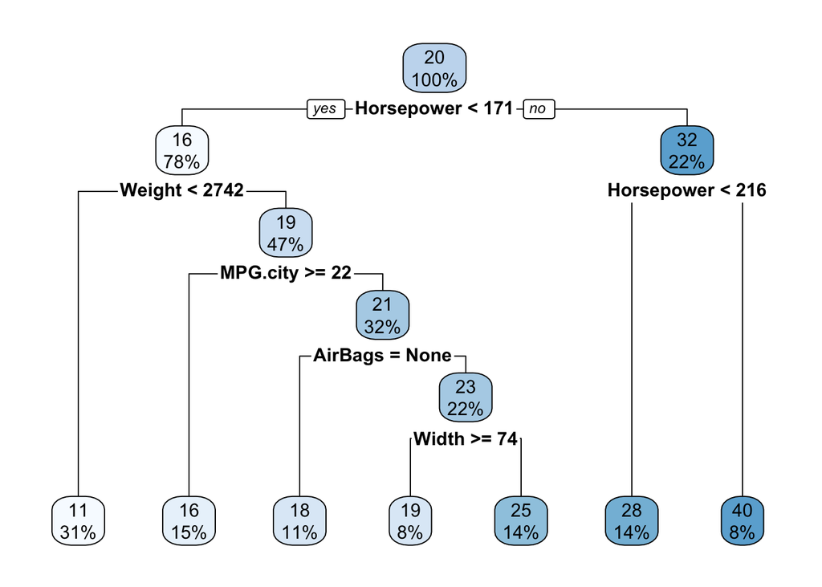

```r
rpart_model2<-rpart(Price~., data=b, method="anova")
rpart.plot(rpart_model2)
```

For a car that weighs 3000 pounds and has horsepower=150, I would predict the price to be 20. If all the other 19 variables are included, the predicted price would be 19 just based on weight and horsepower. However, it didn’t change much.

# Q#3

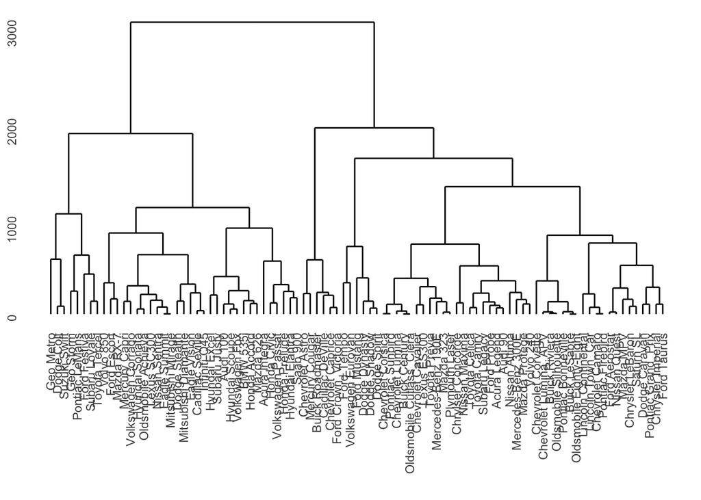

```r
c<-b%>%select(Price, MPG.city, MPG.highway, EngineSize, Horsepower, RPM, Rev.per.mile, Fuel.tank.capacity, Length, Width)
library(ggdendro)
hc<-hclust(dist(c))
ggdendrogram(hc)
```

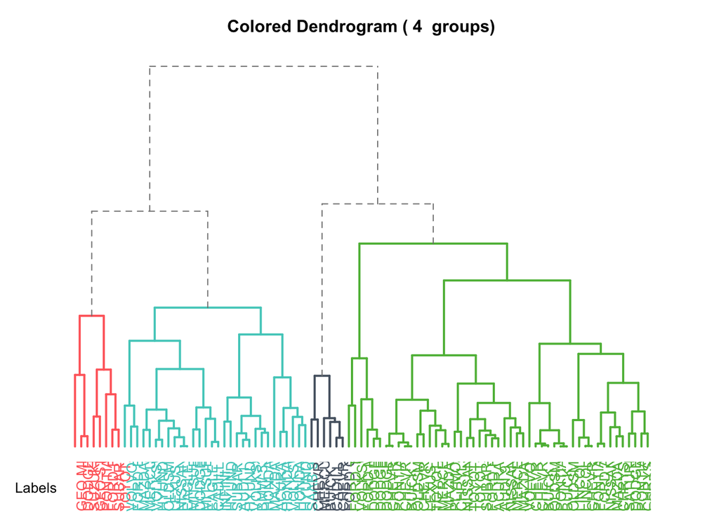

```r
source("http://addictedtor.free.fr/packages/A2R/lastVersion/R/code.R")
A2Rplot(hc, k = 4, boxes = FALSE, col.up = "gray50", col.down = c("#FF6B6B", "#4ECDC4", "#556270", "#5DB944"))
```

I choose to cluster the data into 4 groups. And by the algorithm of hierarchical clustering, I get two groups that have a lot of observations, and th other two that just have a few observations.

# Q#4

```r
c<-na.omit(c)
c<-scale(c)
head(c)
```

```
##                    Price    MPG.city MPG.highway EngineSize  Horsepower
## Acura Integra -0.3736947  0.46877170   0.3589792 -0.8364882 -0.07308831
## Acura Legend   1.4897694 -0.77682168  -0.7663600  0.5130876  1.07250933
## Audi 90        0.9928456 -0.42093785  -0.5788035  0.1274945  0.53789710
## Audi 100       1.8831674 -0.59887976  -0.5788035  0.1274945  0.53789710
## BMW 535i       1.0860189 -0.06505403   0.1714226  0.8022824  1.22525568
## Buick Century -0.3943998 -0.06505403   0.3589792 -0.4508951 -0.64588713
##                      RPM Rev.per.mile Fuel.tank.capacity     Length
## Acura Integra  1.7082298   1.12344082        -1.05645768 -0.4248828
## Acura Legend   0.3675937   0.00563074         0.40723788  0.8077928
## Audi 90        0.3675937  -0.10514323         0.07180765 -0.2194369
## Audi 100       0.3675937   0.40844518         1.35254126  0.6708289
## BMW 535i       0.7027528   0.42858591         1.35254126  0.1914550
## Buick Century -0.1351448   0.46886735        -0.08066064  0.3969009
##                     Width
## Acura Integra -0.36420985
## Acura Legend   0.42965381
## Audi 90       -0.62883107
## Audi 100       0.16503259
## BMW 535i      -0.09958863
## Buick Century -0.09958863
```

```r
library(factoextra)
```

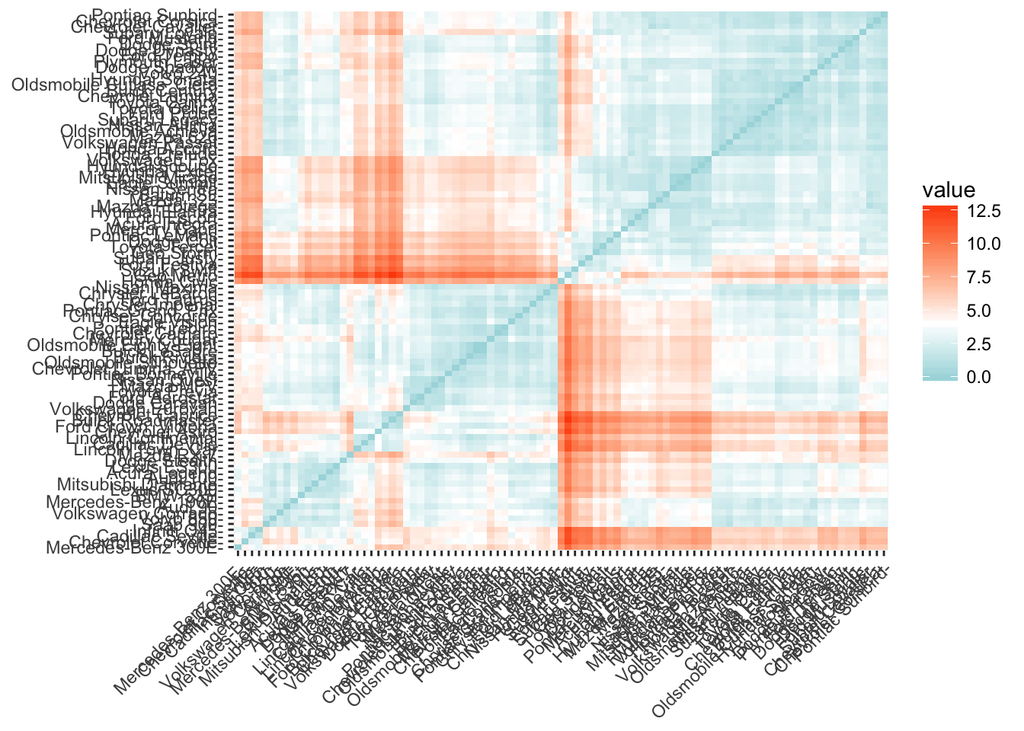

```r
distance<-get_dist(c)
fviz_dist(distance, gradient=list(low = "#00AFBB", mid = "white", high = "#FC4E07"))
```

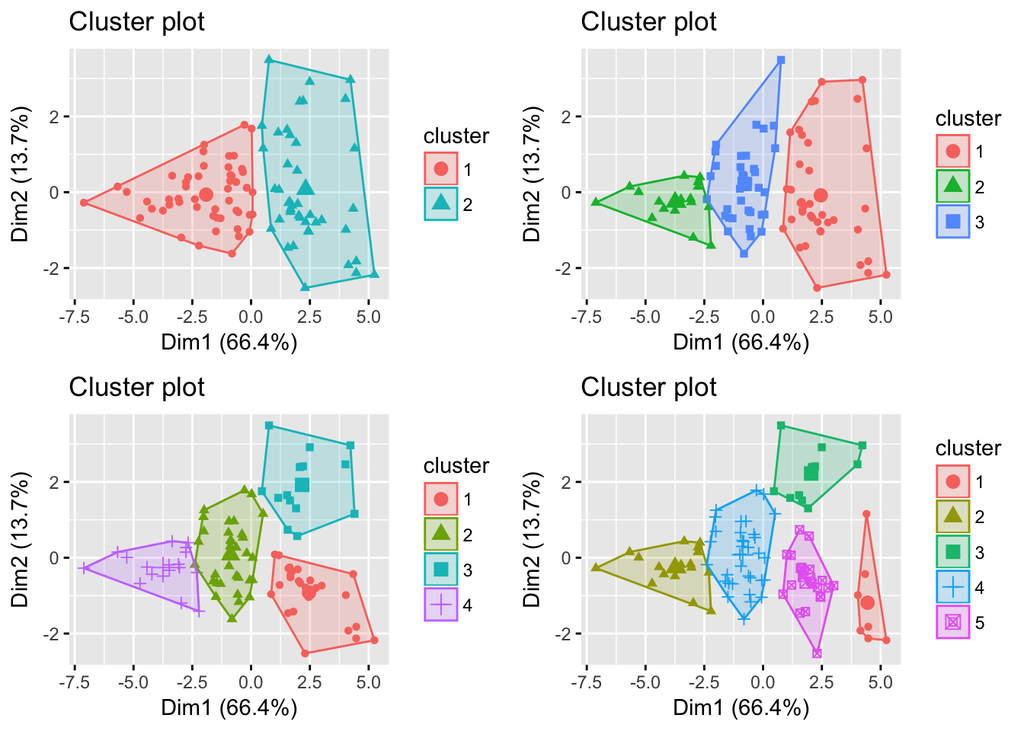

```r
k2<-kmeans(c, centers=2, nstart=25)
k3<-kmeans(c, centers=3, nstart=25)
k4<-kmeans(c, centers=4, nstart=25)
k5<-kmeans(c, centers=5, nstart=25)
p2<-fviz_cluster(k2, geom="point", data = c)
p3<-fviz_cluster(k3, geom="point", data = c)
p4<-fviz_cluster(k4, geom="point", data = c)
p5<-fviz_cluster(k5, geom="point", data = c)
library(gridExtra)
grid.arrange(p2, p3, p4, p5, nrow=2)
```

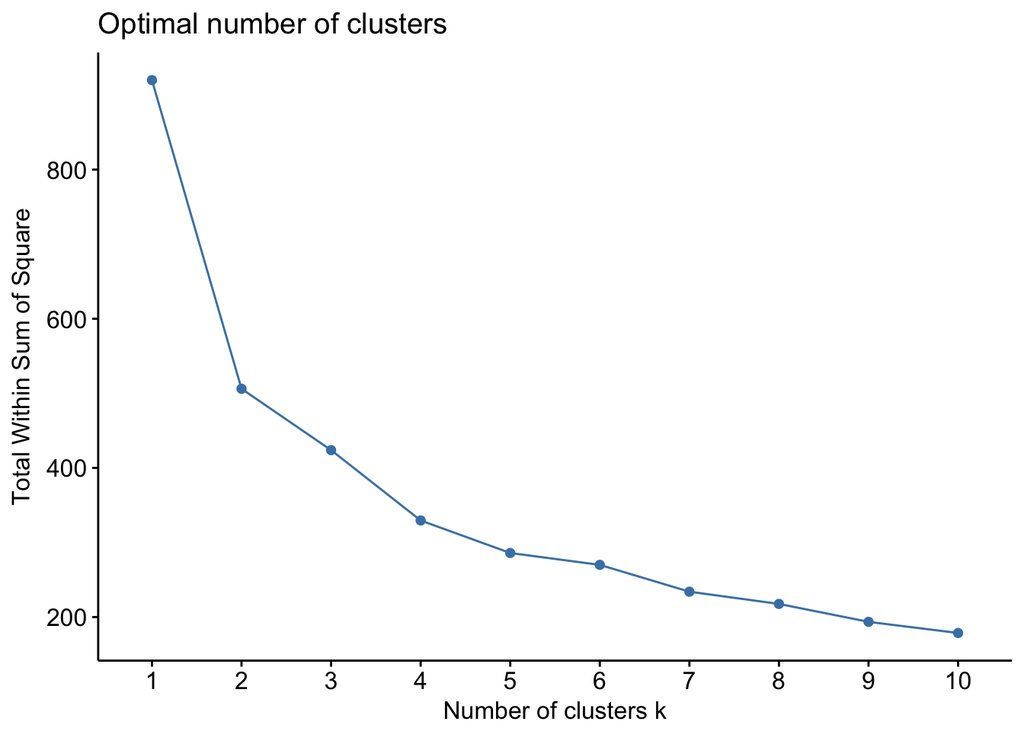

```r
fviz_nbclust(c, kmeans, method="wss")
```

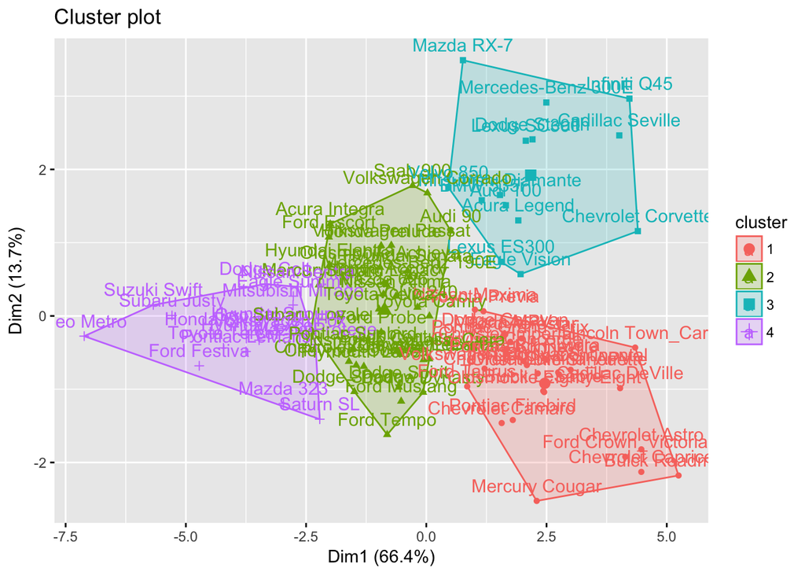

```r
fviz_cluster(k4, data = c)
```

I draw the clusters of 2, 3, 4 and 5. And I plot the total sum of square against the number of clusters to determine the optimal number of clusters. Based on the graph, I would say 4 is the optimal number of clusters, so I draw the k-means clustering graph with 4 clusters again. Comparing it to the graph of the hierarchical clustering, I would say k-means clustering makes more sense, since it doesn’t have any groups that are too small or too big.